# Scholarly API Cookbook

Contents

# …in Mathematica

## Crossref API in Mathematica

by Vishank Patel

**Crossref API documentation:** https://api.crossref.org/swagger-ui/index.html

Also see the CrossRef Mathematica documentation: https://reference.wolfram.com/language/ref/service/CrossRef.html

These recipe examples were tested on January 20, 2022.

*From our testing, we have found that the crossref metadata across publishers and even journals can vary considerably. As a result, it can be easier to work with one journal at a time when using the crossref API (e.g., particulary when trying to extract selected data from records).*

## 1. Basic crossref API call

### Establish Connection

```
crossref = ServiceConnect["CrossRef"]
```

### Request data from crossref API

```
doi = "10.1038/357225a0";
paper = crossref["WorkInformation", "DOI" -> doi];
paper
```

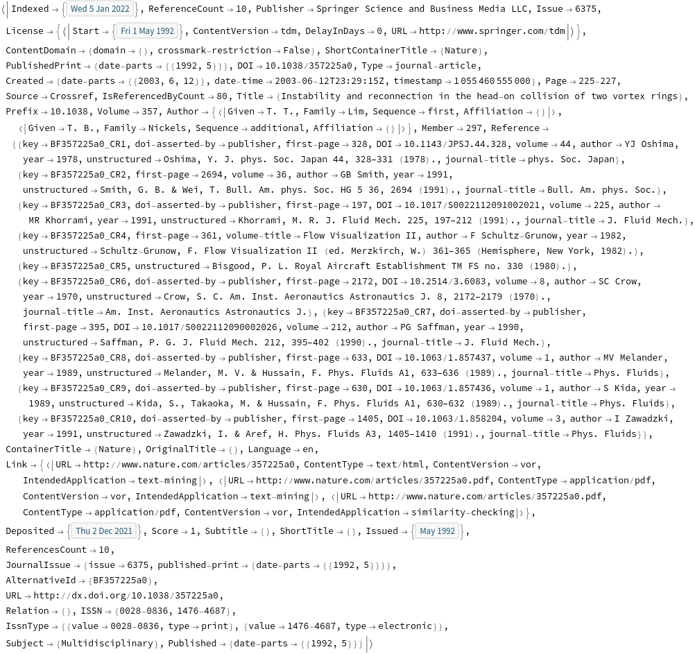

### Format data output

To present the same data in a nice table format, we can use a postfix called “Dataset”.

```
paper // Dataset
```

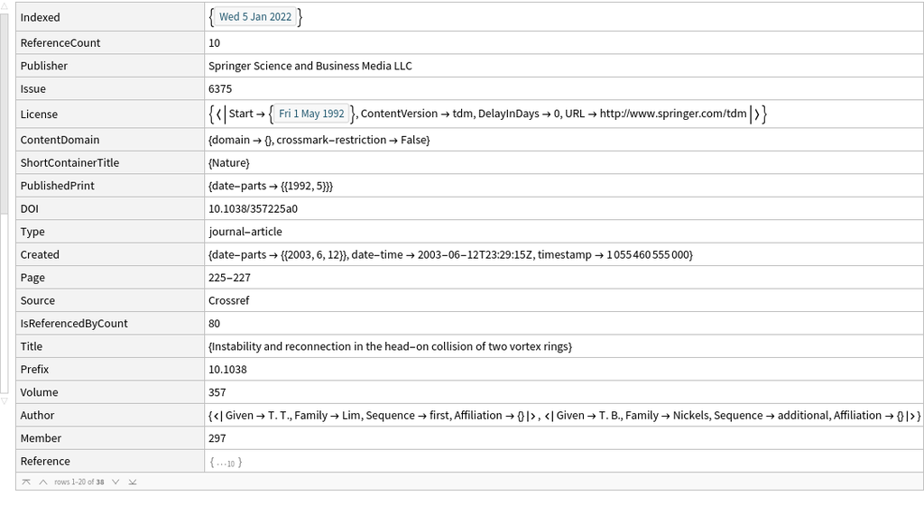

### Select some specific data

```
paper["Title"]
```

```
{Instability and reconnection in the head-on collision of two vortex rings}
```

```
authorNum = 2; (*Second author*)

(*authorNum variable has been created only for clarity,
the same output can be achieved without defining the variable.*)

sAuthor = paper["Author"][[authorNum, "Family"]]
```

```
Nickels
```

```
paper["Reference"][[1]] // Dataset
(*Extracting the first reference*)
```

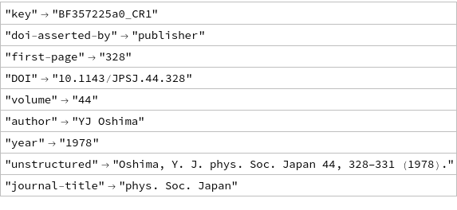

To see the publishing journal for the paper’s first reference, we will first turn the default list output into an “Association”.

```
pAssociation = Association[paper["Reference"][[1]]];
pAssociation["journal-title"]
```

```
phys. Soc. Japan
```

To do this for all the paper’s references,

```
allRefs = paper["Reference"]; (*returns a list of lists*)
allRefsAssoc = Association @@@ allRefs; (*converts lists at the first level into associations*)
allRefsAssoc[[All, "journal-title"]]
```

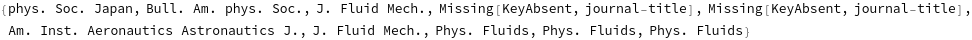

```
% // Dataset
```

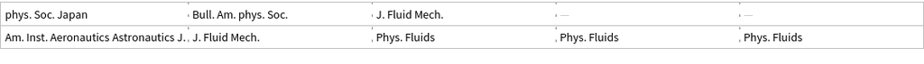

Similarly, we can also extract the reference years.

```
allRefsAssoc[[All, "year"]] // Dataset
```

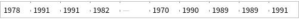

### Request and select data from multiple sources

Let us define three papers using their DOIs, and the request “WorkInformation”.

```
vortexP = crossref["WorkInformation", "DOI" -> "10.1038/357225a0"];
crisprP = crossref["WorkInformation", "DOI" -> "10.1038/nprot.2013.143"];
globalWarmingP = crossref["WorkInformation", "DOI" -> "10.1038/d41586-018-07586-5"];
```

Get article titles:

```
{vortexP[#], crisprP[#], globalWarmingP[#]} &["Title"]
(*Here, # serves as a placeholder, and anything after the & sign is used to replace the #*)
```

```
{{Instability and reconnection in the head-on collision of two vortex rings},

>   {Genome engineering using the CRISPR-Cas9 system},

>   {Global warming will happen faster than we think}}
```

Looking at the publisher, we can see that all of them have been published by Springer Science and Business Media LLC.

```
{vortexP[#], crisprP[#], globalWarmingP[#]} &["Publisher"]
```

```
{Springer Science and Business Media LLC, Springer Science and Business Media LLC,

>   Springer Science and Business Media LLC}
```

Published print date:

[output not shown]

## 2. Acquiring a list of DOIs

Let us extract a list of DOIs by asking for papers from a particular journal from the year 2019 to 2021. Working with the Journal of Cheminformatics, CrossRef can be queried using the journal’s ISSN (International Standard Serial Number), which is 1758-2946.

```
papers = crossref["WorksDataset", "ISSN" -> "1758-2946","IssuedDate" -> {DateObject[{2019}], DateObject[{2021}]}, MaxItems -> 10];
```

As we can see below, all the papers are from J Cheminform.

```
papers[All, "ShortContainerTitle"] //Normal
```

```
{{J Cheminform}, {J Cheminform}, {J Cheminform}, {J Cheminform}, {J Cheminform},

>   {J Cheminform}, {J Cheminform}, {J Cheminform}, {J Cheminform}, {J Cheminform}}
```

Extracting their respective DOIs.

```
doiList = papers[All, "DOI"] //Normal
```

```
{10.1186/s13321-019-0377-0, 10.1186/s13321-020-00463-2, 10.1186/s13321-020-00424-9,

>   10.1186/s13321-019-0373-4, 10.1186/s13321-019-0357-4, 10.1186/s13321-019-0340-0,

>   10.1186/s13321-019-0351-x, 10.1186/s13321-019-0363-6, 10.1186/s13321-020-00468-x,

>   10.1186/s13321-020-00474-z}
```

Note that the number of DOIs can easily be changed by manipulating the MaxItems parameter while querying crossref. If the parameter is not defined, Mathematica sets it to 20.

## 3. Crossref API call with a loop

Now that we know how to extract a list of DOIs, below are a few ways by which we could operate on them.

```
listDOIs = {"10.1093/oso/9780198828044.003.0003", "10.1093/oso/9780198714934.003.0006", "10.7551/mitpress/13811.003.0005", "10.1093/oso/9780190941659.003.0001", "10.7551/mitpress/8996.003.0003", "10.1017/9781107338548.009", "10.1002/9781119557500.ch1", "10.7551/mitpress/8996.003.0016", "10.7551/mitpress/13811.003.0004", "10.1002/9781119557500.ch12"};
```

```
For[i = 1, i <= Length[listDOIs], i++,
 Print[crossref["WorkInformation", "DOI" -> listDOIs[[i]]]["Title"]]]
```

```
{Machine learning with sklearn}
{Statistical machine learning}
{Machine Learning, Statistics, and Data Analytics}
{Why Use Automated Machine Learning?}
{Introduction: Optimization and Machine Learning}
{Adversarial Machine Learning Challenges}
{Introduction to Machine Learning}
{Robust Optimization in Machine Learning}
{Why We Are Interested in Machine Learning}
{Deploying Machine Learning Models}
```

To check their respective publishers:

```
For[i = 1, i <= Length[listDOIs], i++,
 Print[crossref["WorkInformation", "DOI" -> listDOIs[[i]]]["Publisher"]]]
```

```
Oxford University Press
Oxford University Press
The MIT Press
Oxford University Press
The MIT Press
Cambridge University Press
John Wiley & Sons, Inc.
The MIT Press
The MIT Press
John Wiley & Sons, Inc.
```

Extracting author last names from the papers:

As a lot of the sources from the “listDOIs” have missing author information, we will switch to the “doiList” defined in the previous section.

```
For[i = 1, i <= Length[doiList], i++,
 Print[crossref["WorkInformation", "DOI" -> doiList[[i]]]["Author"][[All, "Family"]]]]
```

```
{Thibault, Roe, Facelli, Cheatham}
{Steinberg, Russo, Frey}
{Kuhn, Neumann, Steinbeck, Wittekindt, Zielesny}
{Zhang, Zhang, Li, Wang, Zhang, Hou}
{Kru"ger, Gohlke}
{Rupp, Tkatchenko, Mu"ller, von Lilienfeld}
{Spjuth, Rydberg, Willighagen, Evelo, Jeliazkova}
{Barnard, Downs}
{Mavridis, Mitchell}
{Baumann, Baumann}
```

## 4. Crossref metadata visualization

Let us try to visualize where research papers related to the subject of Tectonic Plates are published using a word cloud. We will start by generating a list of all the publishers.

To achieve that, we loop through a hundred calls to crossref, starting at a random index to get a new paper every time. A pause is also added to not exceed crossref’s call limits.

Note: run `Off[DateObject::date]` to suppress the common DateObject error (irrelevant to our current application).

```
publisherList = {};

For[i = 1, i <= 100, i++,
  {Pause[0.5];
   publisherName := crossref["WorksList", "Query" -> "Tectonic Plates", MaxItems -> 1,
       "StartIndex" -> RandomInteger[{1, 10000}]][[1, "Publisher"]];
   AppendTo[publisherList, publisherName]}];

publisherList
```

```
{US Geological Survey, Test accounts, Geological Society of America,

>   Springer Science and Business Media LLC, CSIRO Publishing, John Wiley & Sons, Inc.,

>   BSI British Standards, Victoria University of Wellington Library,

>   ASTM International, Elsevier, EAGE Publications, John Wiley & Sons, Ltd,

>   American Association for the Advancement of Science (AAAS), AIP, Elsevier, Wiley,

>   Mercator - Revista de Geografia da UFC, Pluto Press, I.B.Tauris, ASTM International,

>   Elsevier, European Association of Geoscientists & Engineers,

>   Simpkin & Marshall ... ;, Springer Netherlands, CRC Press,

>   American Association of Petroleum Geologists, Elsevier, Elsevier,

>   Oxford University Press, University of California Press, ASTM International,

>   Elsevier, Geological Society of America, Oxbow Books,

>   American Geophysical Union (AGU), CRC Press,

>   Natural Resources Canada/CMSS/Information Management, Springer Berlin Heidelberg,

>   US Geological Survey, John Wiley & Sons, Inc., Liverpool University Press,

>   Palgrave Macmillan, BSI British Standards, University of Pennsylvania Press, Inc.,

>   Springer US, American Geophysical Union (AGU), Springer Singapore, Wiley,

>   Canadian Museum of History, Springer Netherlands,

>   American Association for the Advancement of Science (AAAS), Springer Netherlands,

>   Elsevier, Copernicus GmbH, Geological Society of America, John Wiley & Sons, Inc.,

>   Elsevier BV, Geological Society of America, Elsevier,

>   American Association of Petroleum Geologists AAPG/Datapages, Elsevier,

>   The Littman Library of Jewish Civilization, Indonesian Petroleum Association (IPA),

>   American Association of Petroleum Geologists AAPG/Datapages, Elsevier BV,

>   MIT Press - Journals, Springer Science and Business Media LLC,

>   Manchester University Press, Springer International Publishing, Elsevier, Wiley,

>   American Association for the Advancement of Science (AAAS), Copernicus GmbH,

>   University Press of Florida, West Virginia University Libraries, ASM Press,

>   Elsevier, JSTOR, National Bureau of Standards, Springer Berlin Heidelberg,

>   ASTM International, US Geological Survey, AIMS Press, Elsevier,

>   American Geophysical Union (AGU), Elsevier, Informa UK Limited,

>   Cambridge University Press (CUP), John Wiley & Sons, Inc.,

>   Geological Society of America, The University of Hong Kong Libraries,

>   Wiley-VCH Verlag GmbH & Co. KGaA, European Association of Geoscientists & Engineers,

>   Elsevier, University of California Press, Yale University Press, Routledge,

>   Geological Society of America, Elsevier BV, Geological Society of America}
```

```
WordCloud[publisherList]
```

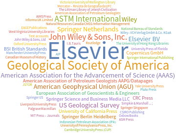

Title word cloud for research from a particular professor:

```
titleList = {};
For[i = 1, i <= 30, i++,
  {Pause[0.5];
   titleTemp := crossref["WorksList", "Query" -> "Aaleti, S.",
      MaxItems -> 1, "StartIndex" -> i, "SortBy" -> "Published"][[1,"Title"]];
   AppendTo[titleList, titleTemp]
   }];
```

```
Flatten[titleList]
```

```
{Experimental Investigation of Surface Preparation on Normal and Ultrahigh-Performance\

>    Concrete Interface Behavior, Experimental Dynamic Testing of Full-Scale\

>    Light-Frame-CLT Wood Shear Wall System,

>   Reinforced-Concrete Shear Walls Retrofitted Using Weakening and Self-Centering:\

>    Numerical Modeling, Seismic Retrofit of Reinforced Concrete Shear Walls to Ensure\

>    Reparability, Searching for Communities,

>   An Experimental and Statistical Study of Normal Strength Concrete (NSC) to Ultra\

>    High Performance Concrete (UHPC) Interface Shear Behavior,

>   Experimental Evaluation of Test Methods to Characterize Tensile Behavior of UHPC,

>   Quantifying Bonding Characteristics between UHPC and Normal-Strength Concrete for\

>    Bridge Deck Application, Long-Span Hybrid Precast Concrete Bridge Girder Using\

>    Ultra-High-Performance Concrete and Normalweight Concrete,

>   Numerical Model for Creep Behavior of Axially Loaded CLT Panels,

>   Experimental investigation of bond behavior of mild steel reinforcement in UHPC,

>   Seismic assessment of a three-story wood building with an integrated CLT-lightframe\

>    system using RTHS, Experimental and analytical investigation of end zone cracking\

>    in BT-78 girders, Hybrid System of Unbonded Post-Tensioned CLT Panels and\

>    Light-Frame Wood Shear Walls, Single precast concrete rocking walls as earthquake\

>    force-resisting elements, Design Optimization of Bridge Decks with Precast UHPC\

>    Waffle Panels, Experimental and Analytical Investigation of UHPC Pile-to-Abutment\

>    Connections, Development length of reinforcing bars in UHPC: An experimental and\

>    analytical investigation, Bridge Decks with Precast UHPC Waffle Panels: A Field\

>    Evaluation and Design Optimization,

>   Precast concrete wall with end columns (PreWEC) for earthquake resistant design,

>   Closure to “Cyclic Response of Reinforced Concrete Walls with Different Anchorage\

>    Details: Experimental Investigation” by Sriram Aaleti, Beth L. Brueggen, Benton\

>    Johnson, Catherine E. French, and Sri Sritharan,

>   Discussion of “Cyclic Response of Reinforced Concrete Walls with Different Anchorage\

>    Details: Experimental Investigation” by Sriram Aaleti, Beth L. Brueggen, Benton\

>    Johnson, Catherine E. French, and Sri Sritharan,

>   Design of Ultrahigh-Performance Concrete Waffle Deck for Accelerated Bridge\

>    Construction, Cyclic Response of Reinforced Concrete Walls with Different Anchorage\

>    Details: Experimental Investigation,

>   Structural Behavior of Waffle Bridge Deck Panels and Connections of Precast\

>    Ultra-High-Performance Concrete,

>   Concept and Finite-Element Modeling of New Steel Shear Connectors for Self-Centering\

>    Wall Systems, A simplified analysis method for characterizing unbonded\

>    post-tensioned precast wall systems,

>   Tests of Structural Walls to Determine Deformation Contributions of Interest for\

>    Performance-Based Design, Seismic Analysis and Design of Precast Concrete Jointed\

>    Wall Systems, Behavior of rectangular concrete walls subjected to simulated seismic\

>    loading}
```

```
WordCloud[ToString[StringRiffle[Flatten[titleList], ""]]]
```

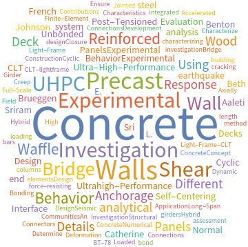

We can also see the frequency of publication for the author using a histogram:

```
DatesList = {};
For[i = 1, i <= 30, i++,
  {Pause[0.5];
   DateTemp := crossref["WorksList", "Query" -> "Aaleti, S.", MaxItems -> 1,
      "StartIndex" -> i][[1, "Published"]];
   AppendTo[DatesList, DateTemp]
   }];
DatesList
```

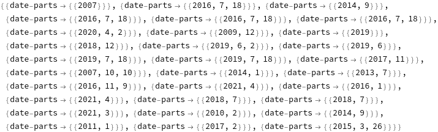

```
DateHistogram[Flatten[Values[DatesList], 2], "Year"]
```

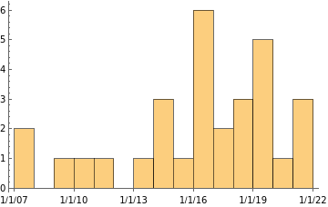